# Marketing Campaigns of Portuguese Bank

Neural Network classifier

Denaldo Lapi, Francesco Aristei, Samy Chouiti

08 June 2022

Delete all the possible objects of R that could have been left in memory:

```r
rm(list = ls())
```

### 0.0.1 Load data

```r
load("data.RData")
```

We can change values of the target variable int ‘yes’ and ‘no’:

```r
testData$y <- as.factor(ifelse(testData$y=='1',"yes","no"))
trainingData$y <- as.factor(ifelse(trainingData$y=='1',"yes","no"))
```

Let’s visualize the main statistics of the training data:

```r
library(dplyr)
library(kableExtra)
library(stats)

trainingData %>%
  summary(.) %>%
  kbl(caption = "Basic statistics. Training data") %>%
  kable_classic(full_width = F, html_font = "Cambria")
```

Basic statistics. Training data

|  | ID | age | balance | duration | campaign | previous | poutcome_failure | poutcome_success | poutcome_unknown | job_admin. | job_blue-collar | job_entrepreneur | job_housemaid | job_management | job_retired | job_self-employed | job_services | job_student | job_technician | job_unemployed | job_unknown | marital_divorced | marital_married | marital_single | education_primary | education_secondary | education_tertiary | education_unknown | default_no | … |
| --- | --- | --- | --- | --- | --- | --- | --- | --- | --- | --- | --- | --- | --- | --- | --- | --- | --- | --- | --- | --- | --- | --- | --- | --- | --- | --- | --- | --- | --- | --- |
|  | Min. : 1 | Min. :19.00 | Min. :-2082 | Min. : 4.0 | Min. : 1.00 | Min. : 0.0000 | Min. :0.0000 | Min. :0.00000 | Min. :0.0000 | Min. :0.0000 | Min. :0.0000 | Min. :0.00000 | Min. :0.00000 | Min. :0.0000 | Min. :0.00000 | Min. :0.00000 | Min. :0.00000 | Min. :0.00000 | Min. :0.0000 | Min. :0.00000 | Min. :0.000000 | Min. :0.0000 | Min. :0.0000 | Min. :0.0000 | Min. :0.000 | Min. :0.000 | Min. :0.0000 | Min. :0.00000 | Min. :0.0000 | … |
|  | 1st Qu.:1149 | 1st Qu.:33.00 | 1st Qu.: 68 | 1st Qu.: 104.0 | 1st Qu.: 1.00 | 1st Qu.: 0.0000 | 1st Qu.:0.0000 | 1st Qu.:0.00000 | 1st Qu.:1.0000 | 1st Qu.:0.0000 | 1st Qu.:0.0000 | 1st Qu.:0.00000 | 1st Qu.:0.00000 | 1st Qu.:0.0000 | 1st Qu.:0.00000 | 1st Qu.:0.00000 | 1st Qu.:0.00000 | 1st Qu.:0.00000 | 1st Qu.:0.0000 | 1st Qu.:0.00000 | 1st Qu.:0.000000 | 1st Qu.:0.0000 | 1st Qu.:0.0000 | 1st Qu.:0.0000 | 1st Qu.:0.000 | 1st Qu.:0.000 | 1st Qu.:0.0000 | 1st Qu.:0.00000 | 1st Qu.:1.0000 | … |
|  | Median :2274 | Median :39.00 | Median : 447 | Median : 185.0 | Median : 2.00 | Median : 0.0000 | Median :0.0000 | Median :0.00000 | Median :1.0000 | Median :0.0000 | Median :0.0000 | Median :0.00000 | Median :0.00000 | Median :0.0000 | Median :0.00000 | Median :0.00000 | Median :0.00000 | Median :0.00000 | Median :0.0000 | Median :0.00000 | Median :0.000000 | Median :0.0000 | Median :1.0000 | Median :0.0000 | Median :0.000 | Median :1.000 | Median :0.0000 | Median :0.00000 | Median :1.0000 | … |
|  | Mean :2271 | Mean :41.06 | Mean : 1406 | Mean : 262.1 | Mean : 2.78 | Mean : 0.5792 | Mean :0.1126 | Mean :0.02913 | Mean :0.8583 | Mean :0.1071 | Mean :0.2097 | Mean :0.03606 | Mean :0.02691 | Mean :0.2141 | Mean :0.05132 | Mean :0.04161 | Mean :0.09126 | Mean :0.01775 | Mean :0.1692 | Mean :0.02802 | Mean :0.006935 | Mean :0.1204 | Mean :0.6144 | Mean :0.2652 | Mean :0.152 | Mean :0.511 | Mean :0.2971 | Mean :0.03994 | Mean :0.9834 | … |
|  | 3rd Qu.:3390 | 3rd Qu.:49.00 | 3rd Qu.: 1480 | 3rd Qu.: 328.0 | 3rd Qu.: 3.00 | 3rd Qu.: 0.0000 | 3rd Qu.:0.0000 | 3rd Qu.:0.00000 | 3rd Qu.:1.0000 | 3rd Qu.:0.0000 | 3rd Qu.:0.0000 | 3rd Qu.:0.00000 | 3rd Qu.:0.00000 | 3rd Qu.:0.0000 | 3rd Qu.:0.00000 | 3rd Qu.:0.00000 | 3rd Qu.:0.00000 | 3rd Qu.:0.00000 | 3rd Qu.:0.0000 | 3rd Qu.:0.00000 | 3rd Qu.:0.000000 | 3rd Qu.:0.0000 | 3rd Qu.:1.0000 | 3rd Qu.:1.0000 | 3rd Qu.:0.000 | 3rd Qu.:1.000 | 3rd Qu.:1.0000 | 3rd Qu.:0.00000 | 3rd Qu.:1.0000 | … |
|  | Max. :4520 | Max. :87.00 | Max. :27359 | Max. :2087.0 | Max. :32.00 | Max. :25.0000 | Max. :1.0000 | Max. :1.00000 | Max. :1.0000 | Max. :1.0000 | Max. :1.0000 | Max. :1.00000 | Max. :1.00000 | Max. :1.0000 | Max. :1.00000 | Max. :1.00000 | Max. :1.00000 | Max. :1.00000 | Max. :1.0000 | Max. :1.00000 | Max. :1.000000 | Max. :1.0000 | Max. :1.0000 | Max. :1.0000 | Max. :1.000 | Max. :1.000 | Max. :1.0000 | Max. :1.00000 | Max. :1.0000 | … |

Test data:

```r
library(dplyr)
library(kableExtra)
library(stats)
testData %>%
  summary(.) %>%
  kbl(caption = "Basic statistics. Test data") %>%
  kable_classic(full_width = F, html_font = "Cambria")
```

Basic statistics. Test data

|  | ID | age | balance | duration | campaign | previous | poutcome_failure | poutcome_success | poutcome_unknown | job_admin. | job_blue-collar | job_entrepreneur | job_housemaid | job_management | job_retired | job_self-employed | job_services | job_student | job_technician | job_unemployed | job_unknown | marital_divorced | marital_married | marital_single | education_primary | education_secondary | education_tertiary | education_unknown | default_no | … |
| --- | --- | --- | --- | --- | --- | --- | --- | --- | --- | --- | --- | --- | --- | --- | --- | --- | --- | --- | --- | --- | --- | --- | --- | --- | --- | --- | --- | --- | --- | --- |
|  | Min. : 6 | Min. :19.00 | Min. : -988.00 | Min. : 5.0 | Min. : 1.000 | Min. : 0.0000 | Min. :0.00000 | Min. :0.00000 | Min. :0.0000 | Min. :0.000 | Min. :0.0000 | Min. :0.00000 | Min. :0.00000 | Min. :0.0000 | Min. :0.00000 | Min. :0.00000 | Min. :0.00000 | Min. :0.00000 | Min. :0.0000 | Min. :0.00000 | Min. :0.00000 | Min. :0.000 | Min. :0.0000 | Min. :0.0000 | Min. :0.0000 | Min. :0.00 | Min. :0.0000 | Min. :0.00000 | Min. :0.0000 | … |
|  | 1st Qu.:1058 | 1st Qu.:34.00 | 1st Qu.: 78.25 | 1st Qu.: 104.0 | 1st Qu.: 1.000 | 1st Qu.: 0.0000 | 1st Qu.:0.00000 | 1st Qu.:0.00000 | 1st Qu.:1.0000 | 1st Qu.:0.000 | 1st Qu.:0.0000 | 1st Qu.:0.00000 | 1st Qu.:0.00000 | 1st Qu.:0.0000 | 1st Qu.:0.00000 | 1st Qu.:0.00000 | 1st Qu.:0.00000 | 1st Qu.:0.00000 | 1st Qu.:0.0000 | 1st Qu.:0.00000 | 1st Qu.:0.00000 | 1st Qu.:0.000 | 1st Qu.:0.0000 | 1st Qu.:0.0000 | 1st Qu.:0.0000 | 1st Qu.:0.00 | 1st Qu.:0.0000 | 1st Qu.:0.00000 | 1st Qu.:1.0000 | … |
|  | Median :2218 | Median :40.00 | Median : 442.50 | Median : 185.0 | Median : 2.000 | Median : 0.0000 | Median :0.00000 | Median :0.00000 | Median :1.0000 | Median :0.000 | Median :0.0000 | Median :0.00000 | Median :0.00000 | Median :0.0000 | Median :0.00000 | Median :0.00000 | Median :0.00000 | Median :0.00000 | Median :0.0000 | Median :0.00000 | Median :0.00000 | Median :0.000 | Median :1.0000 | Median :0.0000 | Median :0.0000 | Median :1.00 | Median :0.0000 | Median :0.00000 | Median :1.0000 | … |
|  | Mean :2210 | Mean :41.54 | Mean : 1378.39 | Mean : 261.9 | Mean : 2.759 | Mean : 0.4035 | Mean :0.09202 | Mean :0.02661 | Mean :0.8814 | Mean :0.102 | Mean :0.2062 | Mean :0.03991 | Mean :0.01663 | Mean :0.2184 | Mean :0.04878 | Mean :0.03548 | Mean :0.09645 | Mean :0.02106 | Mean :0.1741 | Mean :0.02661 | Mean :0.01441 | Mean :0.102 | Mean :0.6341 | Mean :0.2639 | Mean :0.1375 | Mean :0.51 | Mean :0.3049 | Mean :0.04767 | Mean :0.9856 | … |
|  | 3rd Qu.:3375 | 3rd Qu.:48.00 | 3rd Qu.: 1443.25 | 3rd Qu.: 329.0 | 3rd Qu.: 3.000 | 3rd Qu.: 0.0000 | 3rd Qu.:0.00000 | 3rd Qu.:0.00000 | 3rd Qu.:1.0000 | 3rd Qu.:0.000 | 3rd Qu.:0.0000 | 3rd Qu.:0.00000 | 3rd Qu.:0.00000 | 3rd Qu.:0.0000 | 3rd Qu.:0.00000 | 3rd Qu.:0.00000 | 3rd Qu.:0.00000 | 3rd Qu.:0.00000 | 3rd Qu.:0.0000 | 3rd Qu.:0.00000 | 3rd Qu.:0.00000 | 3rd Qu.:0.000 | 3rd Qu.:1.0000 | 3rd Qu.:1.0000 | 3rd Qu.:0.0000 | 3rd Qu.:1.00 | 3rd Qu.:1.0000 | 3rd Qu.:0.00000 | 3rd Qu.:1.0000 | … |
|  | Max. :4521 | Max. :83.00 | Max. :27733.00 | Max. :2029.0 | Max. :28.000 | Max. :24.0000 | Max. :1.00000 | Max. :1.00000 | Max. :1.0000 | Max. :1.000 | Max. :1.0000 | Max. :1.00000 | Max. :1.00000 | Max. :1.0000 | Max. :1.00000 | Max. :1.00000 | Max. :1.00000 | Max. :1.00000 | Max. :1.0000 | Max. :1.00000 | Max. :1.00000 | Max. :1.000 | Max. :1.0000 | Max. :1.0000 | Max. :1.0000 | Max. :1.00 | Max. :1.0000 | Max. :1.00000 | Max. :1.0000 | … |

Variables structure:

```r
str(testData)
```

```
## 'data.frame':    902 obs. of  54 variables:
##  $ ID                   : int  14 51 93 109 111 115 299 300 329 335 ...
##  $ age                  : int  20 45 27 56 21 25 38 32 35 30 ...
##  $ balance              : int  502 844 -195 3391 2488 331 593 759 978 424 ...
##  $ duration             : int  261 1018 391 243 258 170 1484 317 1370 298 ...
##  $ campaign             : int  1 3 1 1 6 4 24 5 3 4 ...
##  $ previous             : int  0 0 0 0 3 0 0 0 3 0 ...
##  $ poutcome_failure     : int  0 0 0 0 0 0 0 0 0 0 ...
##  $ poutcome_success     : int  0 0 0 0 1 0 0 0 1 0 ...
##  $ poutcome_unknown     : int  1 1 1 1 0 1 1 1 0 1 ...
##  $ job_admin.           : int  0 0 0 0 0 0 0 0 0 0 ...
##  $ job_blue-collar      : int  0 1 0 0 0 0 0 1 0 0 ...
##  $ job_entrepreneur     : int  0 0 0 0 0 0 1 0 0 0 ...
##  $ job_housemaid        : int  0 0 0 0 0 0 0 0 0 0 ...
##  $ job_management       : int  0 0 0 0 0 0 0 0 0 1 ...
```

[output cut: 40 more lines]

Levels of the target factor variable:

```r
levels(trainingData$y)
```

```
## [1] "no"  "yes"
```

We can change the levels ordering:

```r
trainingData$y <- relevel(trainingData$y, ref = "yes")
testData$y <- relevel(testData$y, ref = "yes")
levels(trainingData$y)
```

```
## [1] "yes" "no"
```

The positive value is now located on position 1 of the levels.

# 1 NN classifier

We’ ll use the *caret* package for training NN-based models.

At first let’s load the *caret* package:

```r
library("caret")
# set seed for repeating the experiments
set.seed(123)
```

We’ll run the NN model training on the training dataset by applying cross-validation (10-fold) and by using the *F-score* as a validation metric:

```r
fitControl <- trainControl(method = "cv",
                           number = 10,
                           # Estimate class probabilities
                           classProbs = TRUE,
                           summaryFunction = prSummary,
                           verboseIter = FALSE
)
```

## 1.1 Baseline model

Let’s run a simple neural network by specifying the method ‘nnet’ in the ‘train’ function: this method implements a very trivial feed-forward neural network with a single hidden layer.

It is simply composed by: * an input layer * an hidden layer * an output layer

The network has the following hyperparameters that needs to be tuned: * the number of neurons in the hidden layer. These neurons compute a sigmoidal activation function.

- the ‘weight decay’ parameter which applies regularization to prevent overfitting: we’ll tune also the weight decay.

Let’s define the lists of hyperparameters to try:

```r
grid_nn <- expand.grid(
  size = c(5, 10, 15, 20), # neurons in the hidden layer
  decay = c(0.0001, 0.001, 0.01, 0.1)) # decay rate
```

```r
nn.mod1 <- train(y ~ .,
                 data = trainingData, # train data
                 preProcess = c("center","scale"),
                 method = "nnet",
                 trControl = fitControl,
                 tuneGrid = grid_nn,
                 metric = "F",
                 maxit = 5000
)
```

[output not shown]

[output not shown]

[output cut: 210 more lines]

[output not shown]

[output not shown]

[output not shown]

[output cut: 232 more lines]

[output not shown]

[output not shown]

[output cut: 95 more lines]

[output not shown]

[output not shown]

[output not shown]

[output cut: 44 more lines]

[output not shown]

[output not shown]

[output not shown]

[output cut: 9 more lines]

[output not shown]

[output not shown]

[output cut: 58 more lines]

[output not shown]

[output not shown]

[output cut: 10 more lines]

[output not shown]

[output not shown]

[output cut: 28 more lines]

[output not shown]

[output not shown]

[output not shown]

[output cut: 34 more lines]

[output not shown]

[output not shown]

```
## iter1000 value 93.766409
```

[output not shown]

[output cut: 103 more lines]

[output not shown]

[output not shown]

```
## iter1000 value 354.007485
## iter1010 value 354.006141
## iter1020 value 354.005948
```

[output not shown]

[output cut: 72 more lines]

[output not shown]

[output not shown]

[output not shown]

[output cut: 42 more lines]

[output not shown]

[output not shown]

[output not shown]

[output cut: 170 more lines]

[output not shown]

[output not shown]

[output cut: 19 more lines]

[output not shown]

```
## iter1000 value 193.478844
## iter1010 value 193.465113
## iter1020 value 193.461356
## iter1030 value 193.459709
## iter1040 value 193.458550
## iter1050 value 193.458300
```

[output not shown]

[output cut: 82 more lines]

[output not shown]

Print model:

```r
nn.mod1
```

```
## Neural Network
##
## 3605 samples
##   53 predictor
##    2 classes: 'yes', 'no'
##
## Pre-processing: centered (53), scaled (53)
## Resampling: Cross-Validated (10 fold)
## Summary of sample sizes: 3245, 3244, 3244, 3245, 3244, 3244, ...
## Resampling results across tuning parameters:
##
##   size  decay  AUC        Precision  Recall     F
##    5    1e-04  0.2856685  0.4851390  0.4270035  0.4400631
##    5    1e-03  0.2747531  0.4474305  0.3984901  0.4097322
##    5    1e-02  0.3747098  0.4603335  0.3876887  0.4171942
##    5    1e-01  0.4291106  0.4672431  0.3932636  0.4241581
##   10    1e-04  0.3544042  0.3869241  0.4049942  0.3935724
##   10    1e-03  0.3452870  0.4039011  0.3613821  0.3796647
##   10    1e-02  0.3520175  0.3975776  0.3948897  0.3936908
##   10    1e-01  0.3592084  0.3628806  0.3376887  0.3467573
##   15    1e-04  0.3207468  0.4136617  0.4336237  0.4195885
##   15    1e-03  0.2628229  0.3735146  0.4002904  0.3851744
##   15    1e-02  0.2858858  0.3576700  0.3808362  0.3673187
##   15    1e-01  0.3427512  0.4239194  0.3806039  0.3981388
##   20    1e-04        NaN        NaN        NaN        NaN
##   20    1e-03        NaN        NaN        NaN        NaN
##   20    1e-02        NaN        NaN        NaN        NaN
##   20    1e-01        NaN        NaN        NaN        NaN
##
## F was used to select the optimal model using the largest value.
## The final values used for the model were size = 5 and decay = 1e-04.
```

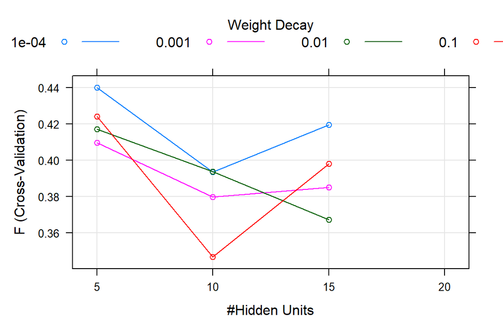

```r
plot(nn.mod1)
```

Print the best tuning parameters that maximize model’s F-score:

```r
nn.mod1$bestTune
```

| size | decay |
| --- | --- |
| 5 | 1e-04 |

Predict test data:

```r
y.nn.pred = predict(nn.mod1, testData)
```

Confusion matrix:

```r
confusionMatrix(y.nn.pred, testData$y, mode = "prec_recall", positive = "yes")
```

```
## Confusion Matrix and Statistics
##
##           Reference
## Prediction yes  no
##        yes  37  28
##        no   67 770
##
##                Accuracy : 0.8947
##                  95% CI : (0.8728, 0.914)
##     No Information Rate : 0.8847
##     P-Value [Acc > NIR] : 0.1885
##
##                   Kappa : 0.3832
##
##  Mcnemar's Test P-Value : 9.67e-05
##
##               Precision : 0.56923
##                  Recall : 0.35577
##                      F1 : 0.43787
##              Prevalence : 0.11530
##          Detection Rate : 0.04102
##    Detection Prevalence : 0.07206
##       Balanced Accuracy : 0.66034
##
##        'Positive' Class : yes
##
```

Variables importance:

```r
#Variable importance by SVM model
varImp(nn.mod1)
```

```
## nnet variable importance
##
##   only 20 most important variables shown (out of 53)
##
##                       Overall
## duration               100.00
## campaign                52.16
## balance                 48.76
## `pdays_Under 1yr`       43.43
## previous                36.20
## month_nov               34.03
## month_apr               33.39
## job_technician          30.12
## month_may               29.01
## age                     27.38
## poutcome_unknown        27.23
## month_oct               26.88
## month_feb               26.80
## `job_blue-collar`       26.44
## poutcome_failure        25.76
## `pdays_Under 1.5yrs`    25.68
## month_sep               24.36
## poutcome_success        23.94
## `pdays_Under 9months`   23.89
## job_admin.              23.77
```

### 1.1.1 Weighting

An approach that we could use to improve the classifier performance on an unbalanced dataset is class weighting. It comsists in imposing a heavier cost when errors are made in the minority class.

We need to create weights for each training sample: * for ‘no’ examples we give a lower weight * for ‘yes’ examples we give an higher weight

Notice that the sum of the weights is 1:

```r
model_weights <- ifelse(trainingData$y == "no",
                        (1/table(trainingData$y)[2]) * 0.5,
                        (1/table(trainingData$y)[1]) * 0.5)
```

We change the grid of parameters: * we reduce the ‘size’ list since the model obtains higher performance with a few hidden neurons:

```r
grid_nn <- expand.grid(
  size = c(2, 5, 10, 12), # neurons in the hidden layer
  decay = c(0.0001, 0.001, 0.01, 0.1)) # decay rate
```

We can now fit the model:

```r
nn.mod2 <- train(y ~ .,
                 data = trainingData, # train data
                 preProcess = c("center","scale"),
                 method = "nnet",
                 trControl = fitControl,
                 tuneGrid = grid_nn,
                 metric = "F",
                 maxit = 5000,
                 weights = model_weights # apply weights
)
```

[output not shown]

[output cut: 1468 more lines]

[output not shown]

Print model:

```r
nn.mod2
```

```
## Neural Network
##
## 3605 samples
##   53 predictor
##    2 classes: 'yes', 'no'
##
## Pre-processing: centered (53), scaled (53)
## Resampling: Cross-Validated (10 fold)
## Summary of sample sizes: 3244, 3244, 3244, 3245, 3245, 3245, ...
## Resampling results across tuning parameters:
##
##   size  decay  AUC        Precision  Recall     F
##    2    1e-04  0.4544568  0.3841319  0.7422184  0.5045780
##    2    1e-03  0.4803193  0.3820701  0.8048780  0.5169551
##    2    1e-02  0.4839796  0.3814069  0.8119628  0.5178598
##    2    1e-01  0.4114330  0.1138889  0.5000000  0.2044888
##    5    1e-04  0.3972923  0.3646985  0.6528455  0.4669891
##    5    1e-03  0.4631200  0.3813490  0.7422764  0.5022465
##    5    1e-02  0.4847871  0.3914274  0.7929152  0.5226144
##    5    1e-01  0.4019493  0.1138889  0.5000000  0.2044888
##   10    1e-04  0.3503504  0.3569069  0.4890825  0.4110099
##   10    1e-03  0.4790744  0.4051934  0.7277584  0.5185032
##   10    1e-02  0.4838414  0.3979023  0.7808362  0.5259002
##   10    1e-01  0.4019672  0.1138889  0.5000000  0.2044888
##   12    1e-04  0.3686314  0.3671755  0.5085366  0.4251541
##   12    1e-03  0.4735970  0.3910121  0.7279326  0.5078400
##   12    1e-02  0.4834351  0.4007933  0.7760163  0.5273914
##   12    1e-01  0.4025631  0.1138889  0.5000000  0.2044888
##
## F was used to select the optimal model using the largest value.
## The final values used for the model were size = 12 and decay = 0.01.
```

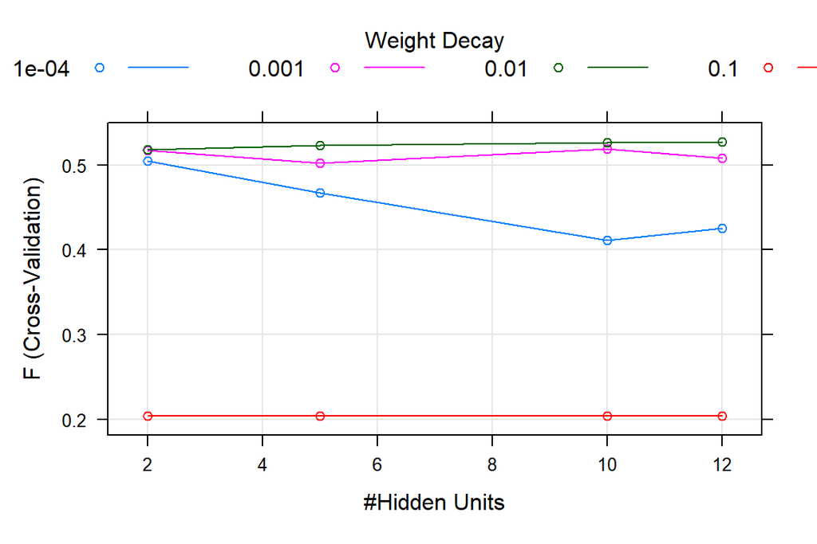

```r
plot(nn.mod2)
```

Print the best tuning parameters that maximize model’s F-score:

```r
nn.mod2$bestTune
```

|  | size | decay |
| --- | --- | --- |
| 15 | 12 | 0.01 |

Predict test data:

```r
y.nn.pred = predict(nn.mod2, testData)
```

Confusion matrix:

```r
confusionMatrix(y.nn.pred, testData$y, mode = "prec_recall", positive = "yes")
```

```
## Confusion Matrix and Statistics
##
##           Reference
## Prediction yes  no
##        yes  79 120
##        no   25 678
##
##                Accuracy : 0.8392
##                  95% CI : (0.8136, 0.8626)
##     No Information Rate : 0.8847
##     P-Value [Acc > NIR] : 1
##
##                   Kappa : 0.436
##
##  Mcnemar's Test P-Value : 5.89e-15
##
##               Precision : 0.39698
##                  Recall : 0.75962
##                      F1 : 0.52145
##              Prevalence : 0.11530
##          Detection Rate : 0.08758
##    Detection Prevalence : 0.22062
##       Balanced Accuracy : 0.80462
##
##        'Positive' Class : yes
##
```

The model achieves a very high balanced accuracy of around 80% and an F1 score of 50%

Variables importance:

```r
#Variable importance by SVM model
varImp(nn.mod2)
```

```
## nnet variable importance
##
##   only 20 most important variables shown (out of 53)
##
##                         Overall
## duration                100.000
## poutcome_success         27.846
## month_oct                24.890
## month_mar                18.248
## month_may                15.619
## campaign                 15.063
## job_retired              14.175
## `pdays_Under 1.5yrs`     13.051
## `pdays_Never contacted`  12.527
## month_sep                11.500
## month_apr                10.957
## loan_no                   9.792
## loan_yes                  9.791
## `pdays_Under 6months`     8.697
## `job_blue-collar`         8.346
## housing_yes               8.137
## housing_no                8.137
## `pdays_Under 3months`     7.959
## poutcome_failure          7.823
## `pdays_Over 1.5yrs`       7.496
```